# Project 1

Jiaming Yan

### For years people are pursuing the key to a question – ‘What makes people happy?’. To me, happiness can be found in two types of ‘things’, a direct way is doing something good to myself such as buying a new pair of shoes, the other is feeling happy after making others happy. Thus, I would like to know that how often do people feel happy in the latter way and why. From this point on, I will separate the data into two parts, one called self while the other named others.

## Happier when making others happy?

```r
library(tidyverse)
library(tidytext)
library(DT)
library(scales)
library(wordcloud2)
library(gridExtra)
library(ngram)
library(shiny)
library(widyr)
```

```r
hm_data <- read_csv("~/Desktop/output/processed_moments.csv")

urlfile<-'https://raw.githubusercontent.com/rit-public/HappyDB/master/happydb/data/demographic.csv'

demo_data <- read_csv(urlfile)
```

```r
hm_data <- hm_data %>%
  inner_join(demo_data, by = "wid") %>%
  select(wid, original_hm, gender, marital, parenthood, reflection_period,
         age, country, ground_truth_category, text) %>%
  mutate(count = sapply(hm_data$text, wordcount)) %>%
  filter(gender %in% c("m", "f")) %>%
  filter(marital %in% c("single", "married")) %>%
  filter(parenthood %in% c("n", "y")) %>%
  filter(reflection_period %in% c("24h", "3m")) %>%
  mutate(reflection_period = fct_recode(reflection_period,
                                        months_3 = "3m", hours_24 = "24h"))

hm_data$original_hm <- tolower(hm_data$original_hm)
```

### If one read every sentence, one will understand, which moment is people being happy for others. Unfortunately, this would not be easily reached by machines, which do not speak any kind of natural language. So, I decided to define few words, that if a text contains one of those words, I roughly consider the text to be ‘let others happy’

```r
others_match <- c("son", "brother", "mom", "children", "neighbour", "sister", "grandmother", "customer", "daughter", "husband", "mother", "father", "grandfather", "parents", "girlfriend", "dad", "boyfriend", "baby", "wife")
```

```r
# Cut the data into two pieces

others <- hm_data[grep(paste(others_match, collapse = "|"),
                      hm_data$original_hm, value = F), ]
self <- hm_data[-grep(paste(others_match, collapse = "|"),
                        hm_data$original_hm, value = F), ]

# Create a bag of words using the text data

bag_others <- others %>%
  unnest_tokens(word, text)
bag_self <- self %>%
  unnest_tokens(word, text)

count_others <- bag_others %>%
  count(word, sort = TRUE)
count_self <- bag_self %>%
  count(word, sort = T)

# Create bigrams using the text data

others_bigrams <- others %>%
  filter(count != 1) %>%
  unnest_tokens(bigram, text, token = "ngrams", n = 2)
self_bigrams <- self %>%
  filter(count != 1) %>%
  unnest_tokens(bigram, text, token = "ngrams", n = 2)

others_counts <- others_bigrams %>%
  separate(bigram, c("word1", "word2"), sep = " ") %>%
  count(word1, word2, sort = TRUE)
self_counts <- self_bigrams %>%
  separate(bigram, c("word1", "word2"), sep = " ") %>%
  count(word1, word2, sort = TRUE)
```

```r
# Specify the user interface for the R Shiny app

ui <- navbarPage("What makes people happy?",
                 tabPanel("Overview", titlePanel(h1("Most Frequent Occurrences",
                                                    align = "center")),
                          sidebarLayout(
                            sidebarPanel(
                              sliderInput(inputId = "topWordcloud",
                                          label = "Number of terms for word cloud:",
                                          min = 5,
                                          max = 100,
                                          value = 50),
                              br(),
                              br(),

                              checkboxInput(inputId = "topFreqB",
                                            label = "Plot Bar Chart",
                                            value = F),
                              sliderInput(inputId = "topBarchart",
                                          label = "Number of terms for bar chart:",
                                          min = 1,
                                          max = 25,
                                          value = 10),
                              br(),
                              br(),

                              checkboxInput(inputId = "topFreqN",
                                            label = "Plot Network Graph",
                                            value = F),
                              sliderInput(inputId = "topNetwork",
                                          label = "Number of edges for network graph:",
                                          min = 1,
                                          max = 150,
                                          value = 50)
                              ),
                            mainPanel(
                              wordcloud2Output(outputId = "WC"),
                              plotOutput(outputId = "figure")
                              )
                            )
                          ),
                 tabPanel("Individual Terms",
                          titlePanel(h1("Comparison of Proportions",
                                        align = "center")),
                          sidebarLayout(
                            sidebarPanel(
                              selectInput(inputId = "attribute",
                                          label = "Select the attribute:",
                                          choices = c("Gender" = "gender",
                                                      "Marital Status" = "marital",
                                                      "Parenthood" = "parenthood",
                                                      "Reflection Period" = "reflection_period")
                              )
                            ),

                            mainPanel(
                              plotOutput(outputId = "scatter")
                              )
                            )
                          ),
                 tabPanel("Pair of Words",
                          titlePanel(h1("Most Frequent Bigrams", align = "center")),
                          sidebarLayout(
                            sidebarPanel(
                              selectInput(inputId = "factor",
                                          label = "Select the attribute:",
                                          choices = c("Gender" = "gender",
                                                      "Marital Status" = "marital",
                                                      "Parenthood" = "parenthood",
                                                      "Reflection Period" = "reflection_period")
                                          ),
                              numericInput(inputId = "topBigrams",
                                           label = "Number of top pairs to view:",
                                           min = 1,
                                           max = 25,
                                           value = 10)
                              ),
                            mainPanel(
                              plotOutput(outputId = "bar")
                              )
                            )
                          ),
                 tabPanel("Data", DT::dataTableOutput("table")
                          )
                 )

# Develop the server for the R Shiny app

server_others <- function(input, output, session) {
  pt1 <- reactive({
    if(!input$topFreqB)
      return(NULL)
    count_others %>%
      slice(1:input$topBarchart) %>%
      mutate(word = reorder(word, n)) %>%
      ggplot(aes(word, n)) +
      geom_col() +
      xlab(NULL) +
      ylab("Word Frequency") +
      coord_flip()
    })

  pt2 <- reactive({
    if(!input$topFreqN)
      return(NULL)
    bigram_graph <- others_counts %>%
      slice(1:input$topNetwork) %>%
      graph_from_data_frame()

    # set.seed(123)
    x <- grid::arrow(type = "closed", length = unit(.1, "inches"))
    ggraph(bigram_graph, layout = "fr") +
      geom_edge_link(aes(edge_alpha = n), show.legend = FALSE,
                     arrow = x, end_cap = circle(.05, 'inches')) +
      geom_node_point(color = "skyblue", size = 3) +
      geom_node_text(aes(label = name), repel = TRUE) +
      theme_void()
  })

  output$WC <- renderWordcloud2({
    count_others %>%
      slice(1:input$topWordcloud) %>%
      wordcloud2(size = 0.6, rotateRatio = 0)
    })

  output$figure <- renderPlot(height = 500, width = 500, {

    ptlist <- list(pt1(),pt2())
    ptlist <- ptlist[!sapply(ptlist, is.null)]
    if(length(ptlist)==0)
      return(NULL)

    lay <- rbind(c(1,1), c(2,2))

    grid.arrange(grobs = ptlist, layout_matrix = lay)
    })

  selectedAttribute <- reactive({
    list(atr = input$attribute)
  })

  output$scatter <- renderPlot({
    temp <- bag_others %>%
      count(!!as.name(selectedAttribute()$atr), word) %>%
      group_by(!!as.name(selectedAttribute()$atr)) %>%
      mutate(proportion = n / sum(n)) %>%
      select(-n) %>%
      spread(!!as.name(selectedAttribute()$atr), proportion)

    ggplot(temp,
           aes_string(x = colnames(temp)[2], y = colnames(temp)[3]),
           color = abs(colnames(temp)[3] - colnames(temp)[2])) +
      geom_abline(color = "gray40", lty = 2) +
      geom_jitter(alpha = 0.1, size = 1, width = 0.3, height = 0.3) +
      geom_text(aes(label = word), check_overlap = TRUE, vjust = 1.5) +
      scale_x_log10(labels = percent_format()) +
      scale_y_log10(labels = percent_format()) +
      scale_color_gradient(limits = c(0, 0.001), low = "darkslategray4", high = "gray75") +
      theme(legend.position="none")
  })

  selectedBigram <- reactive({
    list(var = input$factor)
  })

  output$bar <- renderPlot({
    others_bigrams %>%
      count(!!as.name(selectedBigram()$var), bigram, sort = TRUE) %>%
      group_by(!!as.name(selectedBigram()$var)) %>%
      top_n(input$topBigrams) %>%
      ungroup() %>%
      mutate(bigram = reorder(bigram, n)) %>%
      ggplot(aes(bigram, n, fill = !!as.name(selectedBigram()$var))) +
      geom_col(show.legend = FALSE) +
      facet_wrap(as.formula(paste("~", selectedBigram()$var)), ncol = 2, scales = "free") +
      coord_flip()
  })

  output$table <- DT::renderDataTable({
    DT::datatable(hm_data)
  })
}

server_self <- function(input, output, session) {
  pt1 <- reactive({
    if(!input$topFreqB)
      return(NULL)
    count_self %>%
      slice(1:input$topBarchart) %>%
      mutate(word = reorder(word, n)) %>%
      ggplot(aes(word, n)) +
      geom_col() +
      xlab(NULL) +
      ylab("Word Frequency") +
      coord_flip()
    })

  pt2 <- reactive({
    if(!input$topFreqN)
      return(NULL)
    bigram_graph <- self_counts %>%
      slice(1:input$topNetwork) %>%
      graph_from_data_frame()

    # set.seed(123)
    x <- grid::arrow(type = "closed", length = unit(.1, "inches"))
    ggraph(bigram_graph, layout = "fr") +
      geom_edge_link(aes(edge_alpha = n), show.legend = FALSE,
                     arrow = x, end_cap = circle(.05, 'inches')) +
      geom_node_point(color = "skyblue", size = 3) +
      geom_node_text(aes(label = name), repel = TRUE) +
      theme_void()
  })

  output$WC <- renderWordcloud2({
    count_self %>%
      slice(1:input$topWordcloud) %>%
      wordcloud2(size = 0.6, rotateRatio = 0)
    })

  output$figure <- renderPlot(height = 500, width = 500, {

    ptlist <- list(pt1(),pt2())
    ptlist <- ptlist[!sapply(ptlist, is.null)]
    if(length(ptlist)==0)
      return(NULL)

    lay <- rbind(c(1,1), c(2,2))

    grid.arrange(grobs = ptlist, layout_matrix = lay)
    })

  selectedAttribute <- reactive({
    list(atr = input$attribute)
  })

  output$scatter <- renderPlot({
    temp <- bag_self %>%
      count(!!as.name(selectedAttribute()$atr), word) %>%
      group_by(!!as.name(selectedAttribute()$atr)) %>%
      mutate(proportion = n / sum(n)) %>%
      select(-n) %>%
      spread(!!as.name(selectedAttribute()$atr), proportion)

    ggplot(temp,
           aes_string(x = colnames(temp)[2], y = colnames(temp)[3]),
           color = abs(colnames(temp)[3] - colnames(temp)[2])) +
      geom_abline(color = "gray40", lty = 2) +
      geom_jitter(alpha = 0.1, size = 1, width = 0.3, height = 0.3) +
      geom_text(aes(label = word), check_overlap = TRUE, vjust = 1.5) +
      scale_x_log10(labels = percent_format()) +
      scale_y_log10(labels = percent_format()) +
      scale_color_gradient(limits = c(0, 0.001), low = "darkslategray4", high = "gray75") +
      theme(legend.position="none")
  })

  selectedBigram <- reactive({
    list(var = input$factor)
  })

  output$bar <- renderPlot({
    self_bigrams %>%
      count(!!as.name(selectedBigram()$var), bigram, sort = TRUE) %>%
      group_by(!!as.name(selectedBigram()$var)) %>%
      top_n(input$topBigrams) %>%
      ungroup() %>%
      mutate(bigram = reorder(bigram, n)) %>%
      ggplot(aes(bigram, n, fill = !!as.name(selectedBigram()$var))) +
      geom_col(show.legend = FALSE) +
      facet_wrap(as.formula(paste("~", selectedBigram()$var)), ncol = 2, scales = "free") +
      coord_flip()
  })

  output$table <- DT::renderDataTable({
    DT::datatable(hm_data)
  })
}
```

```r
# Run the R Shiny app

shinyApp(ui, server_others)
```

Shiny applications not supported in static R Markdown documents

```r
# Run the R Shiny app

shinyApp(ui, server_self)
```

Shiny applications not supported in static R Markdown documents

### Let look at the pie chart below, it somehow reveals the ratio of ‘happy for others’ to ‘happy for oneself’. Though the partition of the original dataset may not be accurate and delightful, what I am thinking is, some of the observations from ‘other’ group can be classified to ‘self’ and vice versa. Hopefully, the numbers of the missclassification are the same. After all, I haven’t found a more precise way to group the texts.

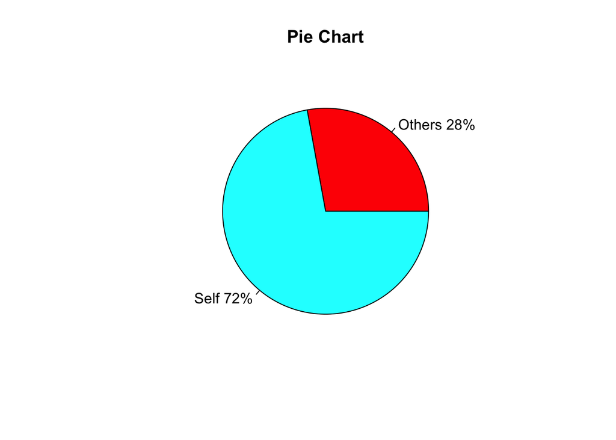

```r
slices <- c(as.numeric(count(others)), as.numeric(count(self)))
lbls <- c("Others", "Self")
pct <- round(slices/sum(slices)*100)
lbls <- paste(lbls, pct)
lbls <- paste(lbls,"%",sep="")
pie(slices, labels = lbls, col = rainbow(length(lbls)), main = "Pie Chart")
```

### To look deeper into the data and find out pairs of words that often come out together, I focus on ‘others’ dataset. With a little bit of math experience, I know that it will take a long long time to get all the pairs.

```r
others_tidy <- data_frame(id = as.character(others$wid), text = others$original_hm)

# Get rid of words that I'm not interested in, well...

word <- c("happy", "ago", "yesterday", "lot", "today", "months", "month", "happier", "happiest", "last", "week", "past", "happiness", "date", "time", "moment", "morning", "noon", "afternoon", "evening", "night", "hours", "loved", "dinner", "son", "brother", "mom", "children", "neighbour", "sister", "grandmother", "customer", "daughter", "husband", "mother", "father", "grandfather", "parents", "girlfriend", "dad", "boyfriend", "baby", "wife", "day", "life", "home", "nice", "family", "care", "person", "phone", "school", "food", "surprised")

stop_words <- stop_words %>%
  bind_rows(mutate(tibble(word), lexicon = "updated"))

others_tidy <- others_tidy %>%
  unnest_tokens(word, text) %>%
  anti_join(stop_words)
```

```r
others_tidy <- others_tidy[1:50000, ]

others_pairs <- pairwise_count(others_tidy, item = word, feature = id, sort = T)

others_pairs
```

| item1 | item2 | n |
| --- | --- | --- |
| surprise | birthday | 53 |
| birthday | surprise | 53 |
| party | birthday | 51 |
| birthday | party | 51 |
| friends | birthday | 45 |
| birthday | friends | 45 |
| excited | birthday | 42 |
| bought | birthday | 42 |
| birthday | excited | 42 |
| birthday | bought | 42 |

[output cut: 9990 more lines]

### By removing some of the words, I found some ‘surprise’, ‘gift’, ‘excited’, which could be either one bought gifts for others making them happy, or others gave gift to the person. However, both way lead to a happy end. ‘Told’ & ‘called’ meaning somebody had good news or been in close relationship. One thing is missing that I really wanted to find the moments that one was happy for somebody’s achievement, which could not be easily detected by machines.

## Caring the senior

### I noticed several observations were older than 90, thus I was curious about what made the senior happy.

```r
senior <- hm_data %>%
  filter(age >= 65 & age != "prefer not to say")

senior <- data_frame(id = as.character(senior$wid),
                          text = senior$original_hm)

# A trigram model

senior %>%
  unnest_tokens(trigram, text, token = "ngrams", n = 3) %>%
  separate(trigram, c("word1", "word2", "word3"), sep = " ") %>%
  filter(!word1 %in% stop_words$word,
         !word2 %in% stop_words$word,
         !word3 %in% stop_words$word) %>%
  count(word1, word2, word3, sort = T)
```

| word1 | word2 | word3 | n |
| --- | --- | --- | --- |
| favorite | baseball | team | 6 |
| baseball | team | won | 5 |
| favorite | baseball | player | 3 |
| 1 | 1 | 2 | 2 |
| 18k | gold | pocket | 2 |
| 4th | birthday | party | 2 |
| april | 2 | 2017 | 2 |
| favorite | soccer | team | 2 |
| gold | pocket | watch | 2 |
| local | animal | shelter | 2 |

[output cut: 385 more lines]

### Interesting! What I did not know is that, they care more about sports! ‘baseball’, ‘team’, ‘soccer’, ‘player’ even ‘boat’ are words related to sports. They are enjoying their lives. Maybe they are just watching games or being part of games, I’m proud of them.

## Summary

### People can be happier by making others happy, if I could find more efficient way to let machine know the meanings of sentences, my point of view would be more supported. However, not many people thought of the question of ‘happy’ in this way, which made the ratio of ‘others’/‘self’ lower. The senior focus on living their own lives, which may due to one reason – time. The long span of years made them think less of such things. Either the happy moment of reunion or the sorrow moment of missing, life still goes on. My data story ends, while happy moments never end.